# Homework 10

Joe Dickerson

2025-04-15

```r
library(faraway)
library(tidyverse)
library(lme4)
library(pbkrtest)
library(RLRsim)

data(eggprod)
```

3. The eggprod dataset concerns an experiment where six pullets were placed into each of 12 pens. Four blocks were formed from groups of three pens based on location. Three treatments were applied. The number of eggs produced was recorded.
1. Make suitable plots of the data and comment.

Treatments E and F seem to generally have higher egg production than treatment O. There does not seem to be a block effect based on the initial exploration of the data.

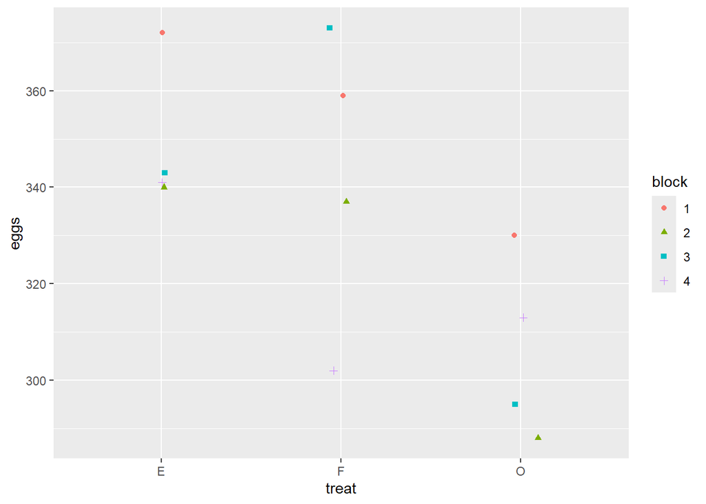

```r
eggprod %>% ggplot(aes(x = treat, y = eggs, color = block, shape = block)) +
  geom_point(position = position_jitter(width = 0.1, height = 0.0))
```

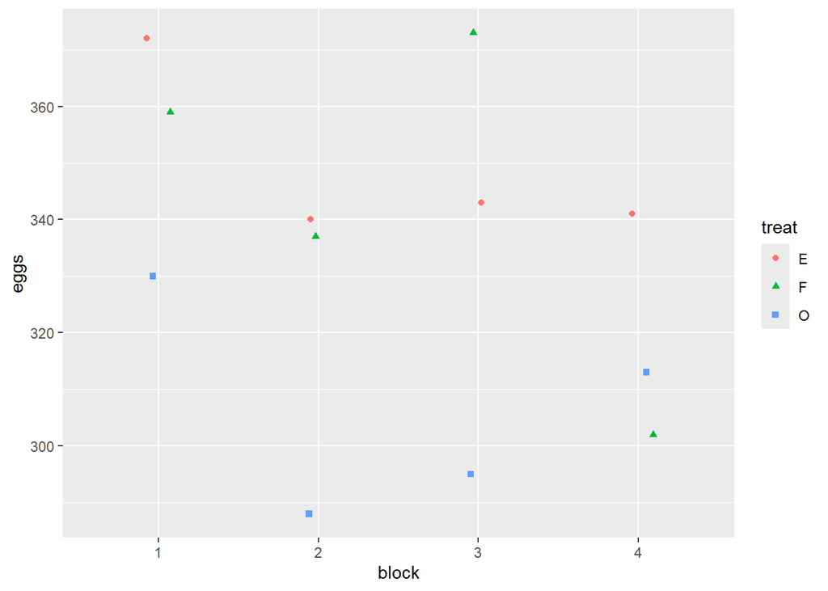

```r
eggprod %>% ggplot(aes(x = block, y = eggs, color = treat, shape = treat)) +
  geom_point(position = position_jitter(width = 0.1, height = 0.0))
```

2. Fit a fixed effects model for the number of eggs produced with the treatments and blocks as predictors. Determine the significance of the two predictors and perform a basic diagnostic check.

It appears that the different treatments are significant, though the difference in blocks might not be significant. We have a satisfactory Q-Q plot, and a satisfactory plot of our fitted values against our residuals.

```r
lmod <- aov(eggs ~ treat + block, eggprod)
summary(lmod)
```

```
##             Df Sum Sq Mean Sq F value Pr(>F)
## treat        2   4212  2106.2   5.444 0.0449 *
## block        3   2330   776.8   2.008 0.2145
## Residuals    6   2322   386.9
## ---
## Signif. codes:  0 '***' 0.001 '**' 0.01 '*' 0.05 '.' 0.1 ' ' 1
```

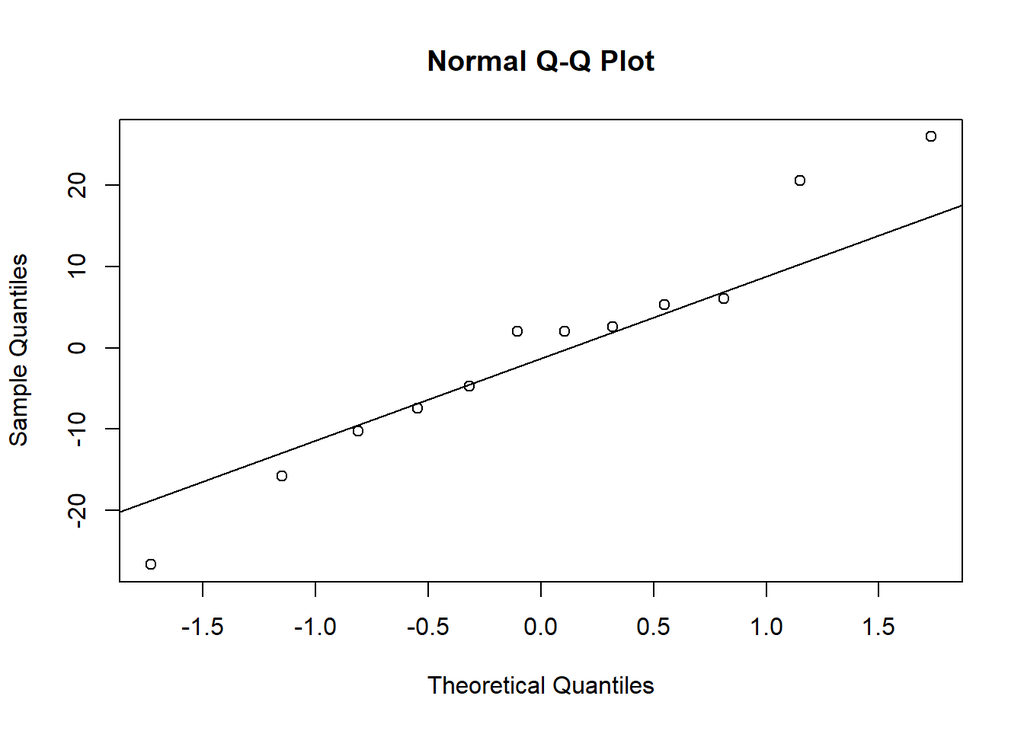

```r
qqnorm(residuals(lmod))
qqline(residuals(lmod))
```

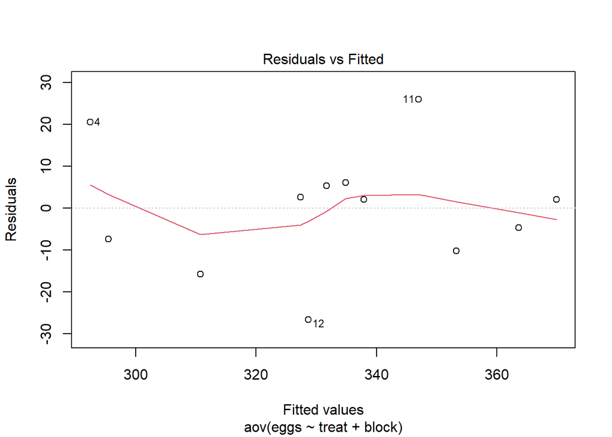

```r
plot(lmod, 1)
```

3. Fit a model for the number of eggs produced with the treatments as fixed effects and the blocks as random effects. Which treatment is best in terms of maximizing production according to the model? Are you sure it is better than other two treatments?

```r
mmod <- lmer(eggs ~ treat + (1|block), eggprod)
summary(mmod)
```

```
## Linear mixed model fit by REML ['lmerMod']
## Formula: eggs ~ treat + (1 | block)
##    Data: eggprod
##
## REML criterion at convergence: 85.4
##
## Scaled residuals:
##      Min       1Q   Median       3Q      Max
## -1.71233 -0.47453 -0.02845  0.64196  1.42942
##
## Random effects:
##  Groups   Name        Variance Std.Dev.
##  block    (Intercept) 129.9    11.40
##  Residual             386.9    19.67
## Number of obs: 12, groups:  block, 4
##
## Fixed effects:
##             Estimate Std. Error t value
## (Intercept)   349.00      11.37  30.702
## treatF         -6.25      13.91  -0.449
## treatO        -42.50      13.91  -3.056
##
## Correlation of Fixed Effects:
##        (Intr) treatF
## treatF -0.612
## treatO -0.612  0.500
```

```r
## treat O ~3 std deviations less than reference
## treat F less than one
```

4. Use the Kenward-Roger approximation for an F-test to check for differences between the treatments. How does the result compare to the fixed effects result?

The result suggests that there is a difference in treatments. This is similar to the result we found in our fixed model, which had a p-value that suggested significance for treatment.

```r
mmod_1 <- lmer(eggs ~ treat + (1|block), eggprod, REML = FALSE)
mmod_2 <- lmer(eggs ~ 1 + (1|block), eggprod, REML = FALSE)

KRmodcomp(mmod_1, mmod_2)
```

```
## large : eggs ~ treat + (1 | block)
## small : eggs ~ 1 + (1 | block)
##         stat    ndf    ddf F.scaling p.value
## Ftest 5.4437 2.0000 6.0000         1 0.04485 *
## ---
## Signif. codes:  0 '***' 0.001 '**' 0.01 '*' 0.05 '.' 0.1 ' ' 1
```

5. Perform the same test but using a bootstrap method. How do the results compare?

We have a p-value of 0.064, which is slightly larger than what we found with the Kenward-Roger approximation, though they seem relatively close to one another given the size of the dataset.

```r
set.seed(123)

PBmodcomp(mmod_1, mmod_2)
```

```
## Bootstrap test; time: 11.19 sec; samples: 1000; extremes: 63;
## large : eggs ~ treat + (1 | block)
## eggs ~ 1 + (1 | block)
##          stat df p.value
## LRT    8.4245  2 0.01481 *
## PBtest 8.4245    0.06394 .
## ---
## Signif. codes:  0 '***' 0.001 '**' 0.01 '*' 0.05 '.' 0.1 ' ' 1
```

6. Test for the significance of the blocks. Does the outcome agree with the fixed effects result?

```r
set.seed(123)

rmod <- lmer(eggs ~ treat + (1|block), eggprod)
nlmod <- lm(eggs ~ treat, eggprod)

LRT <- as.numeric(2*(logLik(rmod)-logLik(nlmod, REML=TRUE)))

lrstatf <- numeric(1000)
for (i in 1:1000) {
  ryield <- unlist(simulate(nlmod))
  nlmodr <- lm(ryield ~ treat, eggprod)
  rmodr <- refit(rmod, ryield)
  lrstatf[i] <- 2*(logLik(rmodr)-logLik(nlmodr, REML=TRUE))
}

mean(lrstatf < 0.00001)
```

```
## [1] 0.562
```

```r
mean(lrstatf > LRT)
```

```
## [1] 0.2
```

```r
exactRLRT(rmod)
```

```
##
##  simulated finite sample distribution of RLRT.
##
##  (p-value based on 10000 simulated values)
##
## data:
## RLRT = 0.51536, p-value = 0.2141
```